# HW2-exploration.qmd

Author

Michelle Yiv

## Setup

```r
# Load libraries

library(tidyverse)
library(here)
library(janitor)
library(dplyr)

library(stars)
library(terra)
library(tmap)
library(stars)
library(sf)
```

## Read in and wrangle data

```r
# Path to the geodatabase folder
gdb_path <- here('data/PMEP_estuary.gdb')

# List all layers (tables and feature classes) in the geodatabase
layers <- st_layers(gdb_path)

# Read in data
estuary <- st_read(
  dsn = gdb_path,
  layer = "PMEP_West_Coast_USA_Estuarine_Biotic_Habitat_Vers1_2"
) %>% clean_names()
```

```
Simple feature collection with 406288 features and 24 fields
Geometry type: GEOMETRY
Dimension:     XY
Bounding box:  xmin: 149307.6 ymin: 72766.55 xmax: 814320.6 ymax: 1892662
Projected CRS: West Coast Custom Mercator
```

```r
# Clean the data set
estuary <- estuary %>%
# Drop extra columns
  select(-c('data_source', 'cmecs_bc_code', 'cmecs_link', 'data_source_vers', 'pmep_estuary_id', 'link', 'cmecs_id', 'acres', 'pmep_poly_id')) %>%
# Rename columns to be more intuitive
  rename(
    name = estuary_name,
    biotic_comp = cmecs_bc_name,
    level = cmecs_level,
    setting = cmecs_bc_setting,
    class = cmecs_bc_class,
    subclass = cmecs_bc_subclass,
    group = cmecs_bc_group,
    community = cmecs_bc_community,
    modifier = cmecs_bc_modifier,
    area_hectares = hectares, # Will convert to km2
    year_data = data_year,
    year_nwi = nwi_year,
    habitat_percent = habitat_source_percent,
    length_shape = shape_length,
    area_shape = shape_area,
    shape = Shape
  ) %>%
  # Convert area to km2
    mutate(area_km2 = area_hectares * 0.01) %>%
    select(-area_hectares) %>%
  # Convert N/A values to true NAs
    mutate(across(where(is.character), ~ na_if(., "N/A")))
```

## Exploratory data visualizations

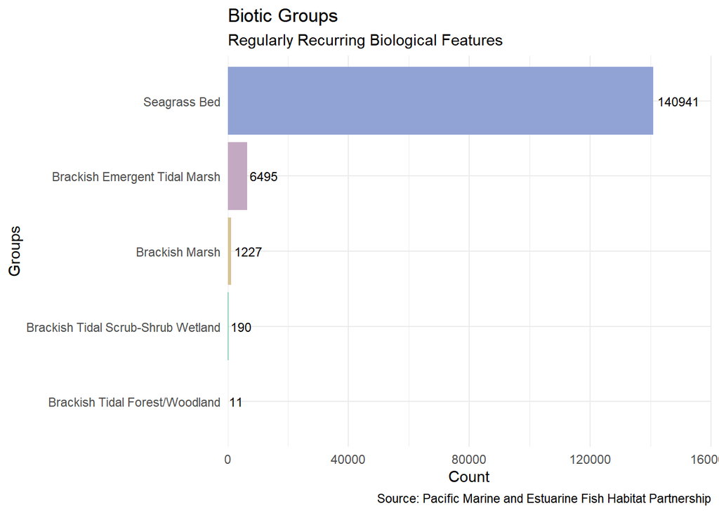

```r
# Visualization 1: Substrate Groups as a simple bar chart
estuary %>%
  mutate(group = na_if(group, "")) %>%  # Convert empty strings to NA
  filter(!is.na(group)) %>% # Remove NA values
# Plot the data
  ggplot(aes(x = fct_reorder(group, group, .fun = length), fill = group)) +
  geom_bar() +
  coord_flip() + # Flip to account for longer labels
  labs(title = "Biotic Groups", x = "Groups", y = "Count",
       caption = "Source: Pacific Marine and Estuarine Fish Habitat Partnership",
       subtitle = "Regularly Recurring Biological Features") +
  scale_y_continuous(expand = c(0, NA), limits = c(0, 160000)) + # Expand axis to make room for eelgrass
  geom_text(stat = "count", aes(label = ..count..), hjust = -0.1, vjust = 0.5,
            size = 3) +
  scale_fill_manual(values = c('#C4A9C2','#D8C397', '#A5CEA4','#3BAF85','#91A2D5')) + theme_minimal() +
  theme(legend.position = "none")
```

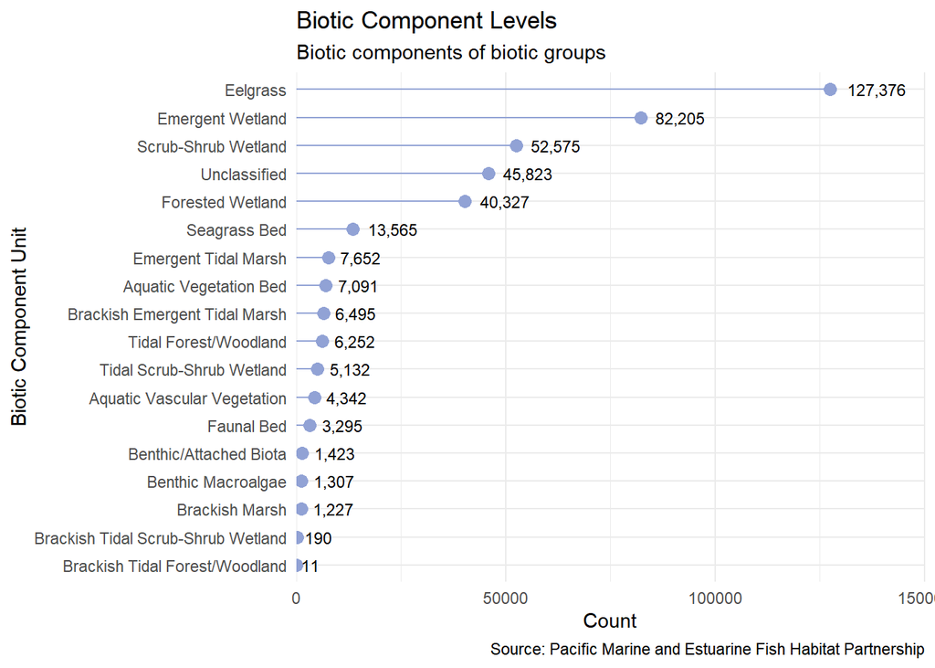

```r
# Visualization #2: Biotic Components - Looking at the makeup of groups

# Generate counts for easier plotting
estuary_counts <- estuary %>%
  st_drop_geometry() %>% # Geometry is unnecessary for these plots
  count(biotic_comp) %>%
  filter(!is.na(biotic_comp)) %>%
  mutate(biotic_comp = fct_reorder(biotic_comp, n))

# Create the lollipop chart
ggplot(estuary_counts, aes(x = biotic_comp, y = n)) +
  geom_segment(aes(xend = biotic_comp, y = 0, yend = n), color = "#91A2D5") +
  geom_point(color = "#91A2D5", size = 3) +
  geom_text(aes(label = scales::comma(n)), hjust = -0.3, vjust = 0.5, size = 3) +
  coord_flip() +
  labs(title = "Biotic Component Levels", x = "Biotic Component Unit", y = "Count",
       caption = "Source: Pacific Marine and Estuarine Fish Habitat Partnership",
       subtitle = 'Biotic components of biotic groups') +
  scale_y_continuous(expand = c(0, NA), limits = c(0, 150000)) +
  theme_minimal()
```

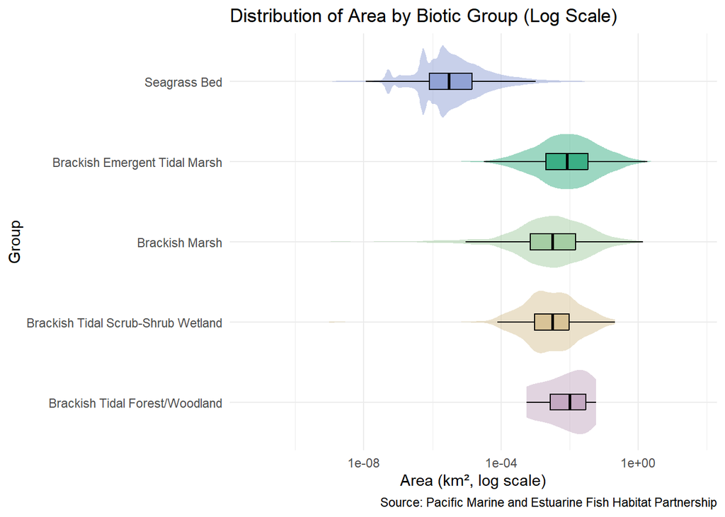

```r
# Visualization #3: Looking at area of each biotic group

# Find counts separately for easier plotting
estuary <- estuary %>%
  mutate(group = na_if(group, "")) %>%
  filter(!is.na(group)) %>%
  mutate(group = fct_reorder(group, group, .fun = length))  # Order by count

# Account for NA values
estuary %>%
  filter(!is.na(area_km2) & area_km2 > 0) %>%  # Ensure no errors for log(0)
# Start plotting
  ggplot(aes(x = group, y = area_km2, fill = group)) +
  geom_violin(alpha = 0.5, color = NA) +
  geom_boxplot(width = 0.2, outlier.shape = NA, color = "black") +
  coord_flip() + # Flip axis for readability
  scale_y_log10() +  # Log scale to handle the really small numbers
  labs(title = "Distribution of Area by Biotic Group (Log Scale)",
       x = "Group",
       y = "Area (km², log scale)",
       caption = "Source: Pacific Marine and Estuarine Fish Habitat Partnership") +
  scale_fill_manual(values = c('#C4A9C2','#D8C397', '#A5CEA4','#3BAF85','#91A2D5')) +
  theme_minimal() +
  theme(legend.position = "none")
```

### Questions

- **1.** What have you learned about your data? Have any potentially interesting patterns emerged?

  I learned that there is very, very little data for the area of each biotic component. I wonder if this is due to limitations in data collection, or if this is reflective of the state of the estuaries.

  Eelgrass makes up a large percentage of the biotic components in estuaries to my surprise, therefore I want to consider taking a look at the other eelgrass data set linked previously. Would it be more informative to take a deeper dive into well documents biota?
- **2.** In HW #1, you outlined some questions that you wanted to answer using these data. Have you made any strides towards answering those questions? If yes, how so? If no, what next steps do you need to take (e.g. I need to create X plot type, I still need to track down Y data, I need to restructure existing data so that you can visualize it in Z ways, etc.)?

  Area, as mentioned in the last question, seems to not have a lot of data and I would not like to answer that question. Instead, I want to visualize biotic component (or group) loss over time. I think making an animated chart would be really cool!
- **3.** What challenges do you foresee encountering with your data? These can be data wrangling and / or visualization challenges.

  I’m thinking now that the area results don’t make the most sense to me, and I wonder if I did something wrong. I’d really like to use that as a statistic, so I can try to find another data set to supplement this one.

  Furthermore, the definitions of the biotic components/groups overlap, and I wonder if staying at the broader group scale would be more accurate (although I would still include some information about the biotic components).

  I am also worried about mapping this data. I was getting many, many errors about the geometry column so I stuck to more simple plots here.